# Appendix 2. Transcript Annotation and Seasonal Gene Expression in Kidney Tissue of the Australian Pygmy Bluetongue Skink, *Tiliqua adelaidensis*

Filter for Transcripts in this list which ALSO have information from the ‘genes of interest’ list

```r
summary_Season.sort_UP_info.GOI <- summary_Season.sort_UP_info %>%
    filter(!is.na(GeneID))

nrow(summary_Season.sort_UP_info.GOI)
```

```
## [1] 1
```

```r
write.csv(summary_Season.sort_UP_info.GOI, "~/@Uni/@Flinders University PhD/RWorkingDir/Workflow-readthedown/ReferenceClusters/summary_Season.sort_UP_info.GOI.csv",
    quote = FALSE, row.names = FALSE, col.names = TRUE)  #write the file to a .csv
```

(note: 1 of the 19 upregulated transcripts that returned a BLASTx result, are represented in the ‘genes of interest’ list)

Do the same for the Seasonally deownregulated transcripts

```r
summary_Season.sort_DOWN <- filter(summary_Season.sort, Regulation ==
    "-1")  #downregulated transcripts denoted as -1
head(summary_Season.sort_DOWN)
```

|  | TranscriptID_3 | Regulation |
| --- | --- | --- |
| 1 | PB.193.6\|07b09f\|path0:5-2520(+)\|transcript/22831 | -1 |
| 2 | PB.193.7\|07b09f\|path0:5-2523(+)\|transcript/22910 | -1 |
| 3 | PB.221.2\|0889ce\|path1:2-3692(+)\|transcript/1643 | -1 |
| 4 | PB.222.2\|0889ce\|path13:1-894(+)\|transcript/23126 | -1 |
| 5 | PB.225.1\|089810\|path3:1-2255(+)\|transcript/24270 | -1 |
| 6 | PB.225.2\|089810\|path3:44-2167(+)\|transcript/11385 | -1 |

```r
nrow(summary_Season.sort_DOWN)
```

```
## [1] 189
```

Extract the full information about the putative identity of these transcripts from the Summary file

```r
summary_Season.sort_DOWN_info <- semi_join(BLASTx.gene.join_Database.Full.PBT.Summary_SeasonExp,
    summary_Season.sort_DOWN, by = "TranscriptID_3")
# head (summary_Season.sort_DOWN_info)
nrow(summary_Season.sort_DOWN_info)
```

```
## [1] 99
```

```r
write.csv(summary_Season.sort_DOWN_info, "~/@Uni/@Flinders University PhD/RWorkingDir/Workflow-readthedown/ReferenceClusters/summary_Season.sort_DOWN_info.csv",
    quote = FALSE, row.names = FALSE, col.names = TRUE)  #write the file to a .csv
```

(note: although there are 189 transcripts significantly downregulated, only 99 of these returned a BLASTx result for their corresponding putative coding region)

Filter for Transcripts in this list which ALSO have information from the ‘genes of interest’ list

```r
summary_Season.sort_DOWN_info.GOI <- summary_Season.sort_DOWN_info %>%
    filter(!is.na(GeneID))

nrow(summary_Season.sort_DOWN_info.GOI)
```

```
## [1] 7
```

```r
write.csv(summary_Season.sort_DOWN_info.GOI, "~/@Uni/@Flinders University PhD/RWorkingDir/Workflow-readthedown/ReferenceClusters/summary_Season.sort_DOWN_info.GOI.csv",
    quote = FALSE, row.names = FALSE, col.names = TRUE)  #write the file to a .csv
```

(note: 7 of the 99 downregulated transcripts that returned a BLASTx result, are represented in the ‘genes of interest’ list)

Visualise the logged Fold Change against Average logged counts per million, in expression of transcripts between seasons using plotsmear: red indicates PValue < 0.05

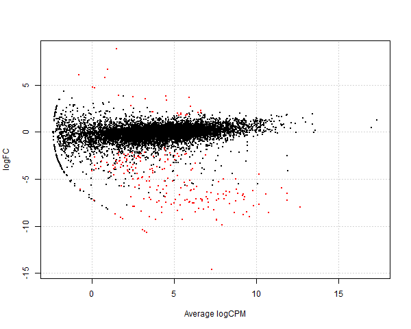

Log Fold Change vs average Log counts per million for expression level comparing March to September season variables among six *T. adelaidensis* individuals. Red dots indicate transcripts with a significant change over season, with p-values <0.05. Counts calculated using Kallisto and EdgeR, for short-read poly(A) selected mRNA sequenced from kidney tissue of six *Tiliqua adelaidensis* individuals, three collected in autumn and three collected in spring, sequenced using Illumina Hi-Seq PE short-read sequencing. Reference sequence isolated from *Tiliqua adelaidensis* skink ID: G6, a representative individual for Pacific Biosciences Iso-Seq long-read transcript sequencing and annotation to generate full length reference transcripts.

```r
png("plotsmear_Season.png", width = 600)
plotSmear(results_Season, de.tags = detags_Season)
```

Visualise differential expression of transcripts between season 1 (September) and 2 (March) with negative Logged PValue against Logged Fold Change in expression: Red indicates a transcript with PValue < 0.05, and Log Fold change > 2

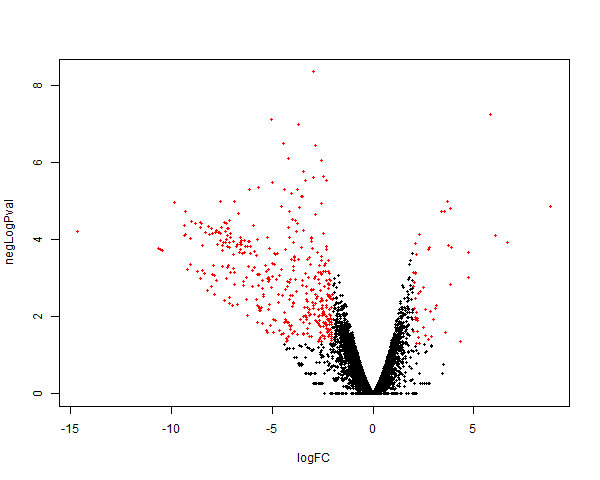

Negative Log of the p-value against Log Fold Change in expression level comparing March to September season variables among six *T. adelaidensis* individuals. Red dots indicate transcripts with a significant change over season, with p-values <0.05 and *also* a log fold change >2. Counts calculated using Kallisto and EdgeR, for short-read poly(A) selected mRNA sequenced from kidney tissue of six *Tiliqua adelaidensis* individuals, three collected in autumn and three collected in spring, sequenced using Illumina Hi-Seq PE short-read sequencing. Reference sequence isolated from *Tiliqua adelaidensis* skink ID: G6, a representative individual for Pacific Biosciences Iso-Seq long-read transcript sequencing and annotation to generate full length reference transcripts.

```r
volcanoData_Season <- cbind(results_Season$table$logFC, -log10(results_Season$table$PValue))
colnames(volcanoData_Season) <- c("logFC", "negLogPval")
DEGs_Season <- results_Season$table$PValue < 0.05 & abs(results_Season$table$logFC) >
    2

point.col_Season <- ifelse(DEGs_Season, "red", "black")
png("volcanoData_Season.png", width = 600)
plot(volcanoData_Season, pch = 16, col = point.col_Season, cex = 0.5)
# pch is shape 1-26 are vectors, cex is size
```

### Group Factor: **Sex**

Create the EdgeR DGE list for use in subsequent analyses

```r
dge_Sex <- DGEList(counts = Kcaught$counts/Kcaught$annotation$Overdispersion,
    genes = Kcaught$annotation, group = sex_group)
# View(dge_Sex) names(dge_Sex)
dge_Sex
```

```
## An object of class "DGEList"
## $counts
##                                                       G1_SepF    G2_SepF
## PB.2.1|002537|path0:1-1624(+)|transcript/18304      278.00000  218.00000
## PB.3.2|00361c|path0:43-2240(+)|transcript/10564    1208.00000 1143.00000
## PB.10.1|004815|path1:5-1713(+)|transcript/17534       0.00000    5.27176
## PB.11.1|004815|path2:1-3039(+)|transcript/3426       42.09258   53.72594
## PB.11.2|004815|path2:1047-3035(+)|transcript/13401    0.00000    0.00000
##                                                       G3_MarF     G4_MarM
## PB.2.1|002537|path0:1-1624(+)|transcript/18304      99.000000  170.000000
## PB.3.2|00361c|path0:43-2240(+)|transcript/10564    990.000000 1467.000000
## PB.10.1|004815|path1:5-1713(+)|transcript/17534      2.475519    1.944563
## PB.11.1|004815|path2:1-3039(+)|transcript/3426      19.475009   16.355109
## PB.11.2|004815|path2:1047-3035(+)|transcript/13401   0.000000    0.000000
##                                                       G5_SepM     G8_MarF
## PB.2.1|002537|path0:1-1624(+)|transcript/18304     131.000000  225.000000
## PB.3.2|00361c|path0:43-2240(+)|transcript/10564    652.000000 2302.000000
## PB.10.1|004815|path1:5-1713(+)|transcript/17534      5.315287    4.370939
## PB.11.1|004815|path2:1-3039(+)|transcript/3426      55.741267   14.183114
## PB.11.2|004815|path2:1047-3035(+)|transcript/13401   0.000000    0.000000
## 9808 more rows ...
##
## $samples
##         group lib.size norm.factors
## G1_SepF     1 10088007            1
## G2_SepF     1 10028560            1
## G3_MarF     1 10002306            1
## G4_MarM     2 10118645            1
## G5_SepM     2  8854300            1
## G8_MarF     1 10310696            1
##
## $genes
##                                                    Length EffectiveLength
## PB.2.1|002537|path0:1-1624(+)|transcript/18304       1530        1207.711
## PB.3.2|00361c|path0:43-2240(+)|transcript/10564      2065        1742.711
## PB.10.1|004815|path1:5-1713(+)|transcript/17534      1612        1289.711
## PB.11.1|004815|path2:1-3039(+)|transcript/3426       2999        2676.711
## PB.11.2|004815|path2:1047-3035(+)|transcript/13401   1965        1642.711
##                                                    Overdispersion
## PB.2.1|002537|path0:1-1624(+)|transcript/18304           1.000000
## PB.3.2|00361c|path0:43-2240(+)|transcript/10564          1.000000
## PB.10.1|004815|path1:5-1713(+)|transcript/17534          2.924537
## PB.11.1|004815|path2:1-3039(+)|transcript/3426           1.425430
## PB.11.2|004815|path2:1047-3035(+)|transcript/13401       1.000000
## 9808 more rows ...
```

Obtain Counts Per Million to standardise count data comparison

```r
myTPM_Sex <- dge_Sex$counts
# head(myTPM_Sex)
```

### Initial Data Exploration

Which values in myCPM are greater than 0.5? This produces a logical matrix with TRUEs and FALSEs. TRUE values are samples with > 0.5 counts in that sample per million

```r
thresh_Sex <- myTPM_Sex > 0.5
# This produces a logical matrix with TRUEs and FALSEs
head(thresh_Sex)
```

```
##                                                    G1_SepF G2_SepF G3_MarF
## PB.2.1|002537|path0:1-1624(+)|transcript/18304        TRUE    TRUE    TRUE
## PB.3.2|00361c|path0:43-2240(+)|transcript/10564       TRUE    TRUE    TRUE
## PB.10.1|004815|path1:5-1713(+)|transcript/17534      FALSE    TRUE    TRUE
## PB.11.1|004815|path2:1-3039(+)|transcript/3426        TRUE    TRUE    TRUE
## PB.11.2|004815|path2:1047-3035(+)|transcript/13401   FALSE   FALSE   FALSE
## PB.13.1|004c10|path2:1-2811(+)|transcript/4993        TRUE    TRUE    TRUE
##                                                    G4_MarM G5_SepM G8_MarF
## PB.2.1|002537|path0:1-1624(+)|transcript/18304        TRUE    TRUE    TRUE
## PB.3.2|00361c|path0:43-2240(+)|transcript/10564       TRUE    TRUE    TRUE
## PB.10.1|004815|path1:5-1713(+)|transcript/17534       TRUE    TRUE    TRUE
## PB.11.1|004815|path2:1-3039(+)|transcript/3426        TRUE    TRUE    TRUE
## PB.11.2|004815|path2:1047-3035(+)|transcript/13401   FALSE   FALSE   FALSE
## PB.13.1|004c10|path2:1-2811(+)|transcript/4993        TRUE    TRUE    TRUE
```

Raw Counts per million and library sizes will be consistent with the Season comparison above. There is no need to plot them again however scripts are included to create separate R objects for downstream application.

CPM distribution with logged CPM

```r
# export the plot as png
png("plotDensities_Sex.png", width = 600)
unfilteredExpr_Sex <- cpm(dge_Sex, log = T)
plotDensities(unfilteredExpr_Sex, col = myPalette, legend = TRUE)
```

Library sizes per sample

```r
# export the plot as png
png("LibSize_Sex.png", width = 600)
# The names argument tells the barplot to use the sample
# names on the x-axis The last argument rotates the axis
# names
barplot(dge_Sex$samples$lib.size, names = colnames(dge_Sex),
    las = 2, col = myPalette, legend = TRUE)
```

Total estimated transcript counts per sample

```r
# export the plot as png
png("boxplot_Sex.png", width = 600)
boxplot(dge_Sex$counts, col = myPalette, las = 2, legend = TRUE)
# title('Boxplot of transcript total estimated counts')
```

Logged total estimated transcript counts per sample

```r
# Get log2 counts per million
logcounts_Sex <- cpm(dge_Sex, log = TRUE)
# Check distributions of samples using boxplots export the
# plot as png
png("boxplot-logcounts_Sex.png", width = 600)
boxplot(logcounts_Sex, xlab = "", ylab = "Log2 counts per million",
    las = 2, col = myPalette, legend = TRUE)
# Let's add a blue horizontal line that corresponds to the
# median logCPM
abline(h = median(logcounts_Sex), col = myPalette, legend = TRUE)
# title('Boxplots of log Counts Per Million')
```

### Calculations

```r
# Data with actual counts, not TPM = 'dge' head(dge_Sex)
# head(myTPM_Sex)
```

Filter out genes with less than 5 reads in 2 samples for each transcript

```r
filter_Sex <- apply(dge_Sex, 1, function(x) length(x[x > 5]) >=
    2)
filtered_Sex <- dge_Sex[filter_Sex, ]
head(filtered_Sex)
```

```
## An object of class "DGEList"
## $counts
##                                                    G1_SepF    G2_SepF
## PB.2.1|002537|path0:1-1624(+)|transcript/18304   278.00000  218.00000
## PB.3.2|00361c|path0:43-2240(+)|transcript/10564 1208.00000 1143.00000
## PB.10.1|004815|path1:5-1713(+)|transcript/17534    0.00000    5.27176
## PB.11.1|004815|path2:1-3039(+)|transcript/3426    42.09258   53.72594
## PB.13.1|004c10|path2:1-2811(+)|transcript/4993   108.03236   68.57706
## PB.14.1|006283|path0:1-1955(+)|transcript/13821  988.84009  671.75142
##                                                    G3_MarF     G4_MarM
## PB.2.1|002537|path0:1-1624(+)|transcript/18304   99.000000  170.000000
## PB.3.2|00361c|path0:43-2240(+)|transcript/10564 990.000000 1467.000000
## PB.10.1|004815|path1:5-1713(+)|transcript/17534   2.475519    1.944563
## PB.11.1|004815|path2:1-3039(+)|transcript/3426   19.475009   16.355109
## PB.13.1|004c10|path2:1-2811(+)|transcript/4993   18.788237   30.061179
## PB.14.1|006283|path0:1-1955(+)|transcript/13821 467.385028  700.161101
##                                                    G5_SepM     G8_MarF
## PB.2.1|002537|path0:1-1624(+)|transcript/18304  131.000000  225.000000
## PB.3.2|00361c|path0:43-2240(+)|transcript/10564 652.000000 2302.000000
## PB.10.1|004815|path1:5-1713(+)|transcript/17534   5.315287    4.370939
## PB.11.1|004815|path2:1-3039(+)|transcript/3426   55.741267   14.183114
## PB.13.1|004c10|path2:1-2811(+)|transcript/4993   33.818826   40.394709
## PB.14.1|006283|path0:1-1955(+)|transcript/13821 441.724674  734.985868
##
## $samples
##         group lib.size norm.factors
## G1_SepF     1 10088007            1
## G2_SepF     1 10028560            1
## G3_MarF     1 10002306            1
## G4_MarM     2 10118645            1
## G5_SepM     2  8854300            1
## G8_MarF     1 10310696            1
##
## $genes
##                                                 Length EffectiveLength
## PB.2.1|002537|path0:1-1624(+)|transcript/18304    1530        1207.711
## PB.3.2|00361c|path0:43-2240(+)|transcript/10564   2065        1742.711
## PB.10.1|004815|path1:5-1713(+)|transcript/17534   1612        1289.711
## PB.11.1|004815|path2:1-3039(+)|transcript/3426    2999        2676.711
## PB.13.1|004c10|path2:1-2811(+)|transcript/4993    2714        2391.711
## PB.14.1|006283|path0:1-1955(+)|transcript/13821   1920        1597.711
##                                                 Overdispersion
## PB.2.1|002537|path0:1-1624(+)|transcript/18304        1.000000
## PB.3.2|00361c|path0:43-2240(+)|transcript/10564       1.000000
## PB.10.1|004815|path1:5-1713(+)|transcript/17534       2.924537
## PB.11.1|004815|path2:1-3039(+)|transcript/3426        1.425430
## PB.13.1|004c10|path2:1-2811(+)|transcript/4993        1.064496
## PB.14.1|006283|path0:1-1955(+)|transcript/13821       1.091177
```

Run calculations

```r
dge_Sex <- calcNormFactors(dge_Sex)
dge_Sex <- estimateCommonDisp(dge_Sex)
dge_Sex <- estimateTagwiseDisp(dge_Sex)
```

```r
dge_Sex$common.dispersion
```

```
## [1] 0.2178922
```

```r
head(dge_Sex$tagwise.dispersion)
```

```
## [1] 0.1319103 0.2089947 0.3706877 0.3181733 0.4299255 0.2331927
```

### Differentially Expressed Genes:

View the top ten ‘differentially expressed genes’

```r
results_Sex <- exactTest(dge_Sex)
topTags(results_Sex)
```

```
## Comparison of groups:  2-1
##                                                   Length EffectiveLength
## PB.2770.1|6751e7|path1:1-1210(+)|transcript/22021   1103        780.7106
## PB.2769.1|6751e7|path0:4-1327(+)|transcript/21195   1136        813.7106
## PB.979.1|25edbb|path0:1-3100(+)|transcript/3575     3066       2743.7106
## PB.3135.1|74403d|path0:1-863(+)|transcript/23390     825        502.7858
## PB.5826.1|dd0edc|path1:1-2280(+)|transcript/9146    2280       1957.7106
## PB.637.1|1826ff|path3:1-1155(+)|transcript/22860     905        582.7631
## PB.2180.1|51f17e|path0:1-673(+)|transcript/24169     469        155.3070
## PB.4152.1|9a8a98|path2:1-992(+)|transcript/22901     896        573.7631
## PB.725.1|1b70a4|path2:1-1745(+)|transcript/16546    1705       1382.7106
## PB.193.9|07b09f|path0:5-2700(+)|transcript/23445     647        325.3615
##                                                   Overdispersion    logFC
## PB.2770.1|6751e7|path1:1-1210(+)|transcript/22021       2.871719 7.965249
## PB.2769.1|6751e7|path0:4-1327(+)|transcript/21195       1.766850 8.089864
## PB.979.1|25edbb|path0:1-3100(+)|transcript/3575         1.024380 8.364555
## PB.3135.1|74403d|path0:1-863(+)|transcript/23390        1.037547 7.812164
## PB.5826.1|dd0edc|path1:1-2280(+)|transcript/9146        1.000000 7.091370
## PB.637.1|1826ff|path3:1-1155(+)|transcript/22860        1.173526 7.639690
## PB.2180.1|51f17e|path0:1-673(+)|transcript/24169        1.000000 7.617367
## PB.4152.1|9a8a98|path2:1-992(+)|transcript/22901        1.309409 8.194551
## PB.725.1|1b70a4|path2:1-1745(+)|transcript/16546        1.000000 4.156773
## PB.193.9|07b09f|path0:5-2700(+)|transcript/23445        1.618587 6.510361
##                                                      logCPM       PValue
## PB.2770.1|6751e7|path1:1-1210(+)|transcript/22021  5.666695 2.550012e-43
## PB.2769.1|6751e7|path0:4-1327(+)|transcript/21195  8.292470 5.483625e-36
## PB.979.1|25edbb|path0:1-3100(+)|transcript/3575    4.081070 1.328872e-25
## PB.3135.1|74403d|path0:1-863(+)|transcript/23390   2.953564 1.640197e-24
## PB.5826.1|dd0edc|path1:1-2280(+)|transcript/9146   3.164706 1.013885e-23
## PB.637.1|1826ff|path3:1-1155(+)|transcript/22860   7.524509 2.471147e-20
## PB.2180.1|51f17e|path0:1-673(+)|transcript/24169   9.391923 3.726989e-20
## PB.4152.1|9a8a98|path2:1-992(+)|transcript/22901   6.841911 6.409448e-20
## PB.725.1|1b70a4|path2:1-1745(+)|transcript/16546   5.897672 2.689880e-19
## PB.193.9|07b09f|path0:5-2700(+)|transcript/23445  11.876401 3.730622e-18
##                                                            FDR
## PB.2770.1|6751e7|path1:1-1210(+)|transcript/22021 2.502327e-39
## PB.2769.1|6751e7|path0:4-1327(+)|transcript/21195 2.690541e-32
## PB.979.1|25edbb|path0:1-3100(+)|transcript/3575   4.346740e-22
## PB.3135.1|74403d|path0:1-863(+)|transcript/23390  4.023813e-21
## PB.5826.1|dd0edc|path1:1-2280(+)|transcript/9146  1.989850e-20
## PB.637.1|1826ff|path3:1-1155(+)|transcript/22860  4.041561e-17
## PB.2180.1|51f17e|path0:1-673(+)|transcript/24169  5.224707e-17
## PB.4152.1|9a8a98|path2:1-992(+)|transcript/22901  7.861989e-17
## PB.725.1|1b70a4|path2:1-1745(+)|transcript/16546  2.932865e-16
## PB.193.9|07b09f|path0:5-2700(+)|transcript/23445  3.660859e-15
```

Output the top 25 table of values based on calculated PValue

```r
tab_Sex <- topTags(results_Sex, n = 25, sort.by = "PValue")
# head(tab_Sex)
write.table(tab_Sex, file = "Kgenelist-Top25_Sex.txt")
```

Output the entire table of values

```r
tab_Sex_all <- topTags(results_Sex, n = Inf, sort.by = "PValue")
write.table(tab_Sex_all, file = "Kgenelist_Sex.txt")
```

Output summary expression data

```r
dim(results_Sex)
```

```
## [1] 9813    3
```

```r
summary(de_Sex <- decideTests(results_Sex))
```

```
##         2-1
## Down     27
## NotSig 9422
## Up      364
```

```r
summary_Sex <- (de_Sex <- decideTests(results_Sex))

write.table(summary_Sex, file = "summary_Sex.txt")

detags_Sex <- rownames(dge_Sex)[as.logical(de_Sex)]
# head(detags_Sex) head(results_Sex)
```

Filter and sort this summary to only include upregulated and downregulated transcripts

```r
summary_Sex.sort <- read.csv("./summary_Sex.txt", sep = " ",
    row.names = NULL, header = TRUE, stringsAsFactors = FALSE)
summary_Sex.sort <- summary_Sex.sort %>%
    rename(TranscriptID_3 = row.names, Regulation = X2.1)
```

filter out the transcripts which are significantly upregulated when compared by sex

```r
summary_Sex.sort_UP <- filter(summary_Sex.sort, Regulation ==
    "1")  #upregulated transcripts denoted as +1
head(summary_Sex.sort_UP)
```

|  | TranscriptID_3 | Regulation |
| --- | --- | --- |
| 1 | PB.48.1\|01e359\|path4:1-3511(+)\|transcript/2176 | 1 |
| 2 | PB.48.2\|01e359\|path4:4-3376(+)\|transcript/2493 | 1 |
| 3 | PB.147.1\|0620ba\|path0:1-1756(+)\|transcript/23387 | 1 |
| 4 | PB.147.3\|0620ba\|path0:1-1628(+)\|transcript/24333 | 1 |
| 5 | PB.193.1\|07b09f\|path0:1-2724(+)\|transcript/21409 | 1 |
| 6 | PB.193.2\|07b09f\|path0:3-2528(+)\|transcript/11304 | 1 |

```r
nrow(summary_Sex.sort_UP)
```

```
## [1] 364
```

Extract the full information about the putative identiry of these transcripts from the Summary file

```r
summary_Sex.sort_UP_info <- semi_join(BLASTx.gene.join_Database.Full.PBT.Summary,
    summary_Sex.sort_UP, by = "TranscriptID_3")
# head (summary_Sex.sort_UP_info)
nrow(summary_Sex.sort_UP_info)
```

```
## [1] 210
```

```r
write.csv(summary_Sex.sort_UP_info, "~/@Uni/@Flinders University PhD/RWorkingDir/Workflow-readthedown/ReferenceClusters/summary_Sex.sort_UP_info.csv",
    quote = FALSE, row.names = FALSE, col.names = TRUE)  #write the file to a .csv
```

(note: although there are 364 transcripts significantly upregulated, only 210 of these returned a BLASTx result for their corresponding putative coding region)

Filter for Transcripts in this list which ALSO have information from the ‘genes of interest’ list

```r
summary_Sex.sort_UP_info.GOI <- summary_Sex.sort_UP_info %>%
    filter(!is.na(GeneID))

nrow(summary_Sex.sort_UP_info.GOI)
```

```
## [1] 15
```

```r
write.csv(summary_Sex.sort_UP_info.GOI, "~/@Uni/@Flinders University PhD/RWorkingDir/Workflow-readthedown/ReferenceClusters/summary_Sex.sort_UP_info.GOI.csv",
    quote = FALSE, row.names = FALSE, col.names = TRUE)  #write the file to a .csv
```

(note: 15 of the 210 upregaulted transcripts that returned a BLASTx result, are represented in the ‘genes of interest’ list)

Do the same for the deownregulated transcripts

```r
summary_Sex.sort_DOWN <- filter(summary_Sex.sort, Regulation ==
    "-1")  #downregulated transcripts denoted as -1
head(summary_Sex.sort_DOWN)
```

|  | TranscriptID_3 | Regulation |
| --- | --- | --- |
| 1 | PB.687.3\|1a3601\|path0:17-1696(+)\|transcript/17363 | -1 |
| 2 | PB.871.3\|206114\|path0:182-1900(+)\|transcript/16557 | -1 |
| 3 | PB.953.1\|24d6a9\|path0:1-2789(+)\|transcript/5211 | -1 |
| 4 | PB.1210.1\|2ea8f7\|path0:1-2553(+)\|transcript/7797 | -1 |
| 5 | PB.1762.2\|4279e1\|path0:18-2114(+)\|transcript/11272 | -1 |
| 6 | PB.1863.3\|46a928\|path18:46-1843(+)\|transcript/14672 | -1 |

```r
nrow(summary_Sex.sort_DOWN)
```

```
## [1] 27
```

Extract the full information about the putative identiry of these transcripts from the Summary file

```r
summary_Sex.sort_DOWN_info <- semi_join(BLASTx.gene.join_Database.Full.PBT.Summary,
    summary_Sex.sort_DOWN, by = "TranscriptID_3")
# head (summary_Sex.sort_DOWN_info)
nrow(summary_Sex.sort_DOWN_info)
```

```
## [1] 24
```

```r
write.csv(summary_Sex.sort_DOWN_info, "~/@Uni/@Flinders University PhD/RWorkingDir/Workflow-readthedown/ReferenceClusters/summary_Sex.sort_DOWN_info.csv",
    quote = FALSE, row.names = FALSE, col.names = TRUE)  #write the file to a .csv
```

(note: although there are 27 transcripts significantly downregulated, 24 of these returned a BLASTx result for their corresponding putative coding region)

Filter for Transcripts in this list which ALSO have information from the ‘genes of interest’ list

```r
summary_Sex.sort_DOWN_info.GOI <- summary_Sex.sort_DOWN_info %>%
    filter(!is.na(GeneID))

nrow(summary_Sex.sort_DOWN_info.GOI)
```

```
## [1] 3
```

```r
write.csv(summary_Sex.sort_DOWN_info.GOI, "~/@Uni/@Flinders University PhD/RWorkingDir/Workflow-readthedown/ReferenceClusters/summary_Sex.sort_DOWN_info.GOI.csv",
    quote = FALSE, row.names = FALSE, col.names = TRUE)  #write the file to a .csv
```

(note: 3 of the 24 downregaulted transcripts that returned a BLASTx result, are represented in the ‘genes of interest’ list)

Visualise the logged Fold Change against Average logged counts per million, in expression of transcripts between sex 1 (Female) and 2 (Male) using plotsmear: red indicates PValue < 0.05

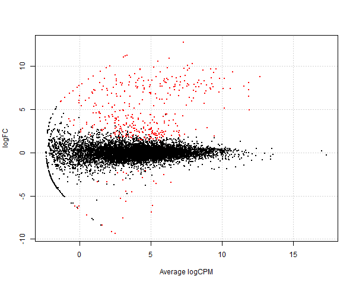

Log Fold Change vs average Log counts per million for expression level comparing Male to Female sex variables among six *T. adelaidensis* individuals. Red dots indicate transcripts with a significant change between sexes, with p-values <0.05. Counts calculated using Kallisto and EdgeR, for short-read poly(A) selected mRNA sequenced from kidney tissue of six *Tiliqua adelaidensis* individuals, three collected in autumn and three collected in spring, sequenced using Illumina Hi-Seq PE short-read sequencing. Reference sequence isolated from *Tiliqua adelaidensis* skink ID: G6, a representative individual for Pacific Biosciences Iso-Seq long-read transcript sequencing and annotation to generate full length reference transcripts.

```r
png("plotsmear_Sex.png", width = 600)
plotSmear(results_Sex, de.tags = detags_Sex)
```

Visualise differential expression of transcripts between sex 1 (Female) and 2 (Male) with negative Logged PValue against Logged Fold Change in expression: Red indicates a transcript with PValue < 0.05, and Log Fold change > 2

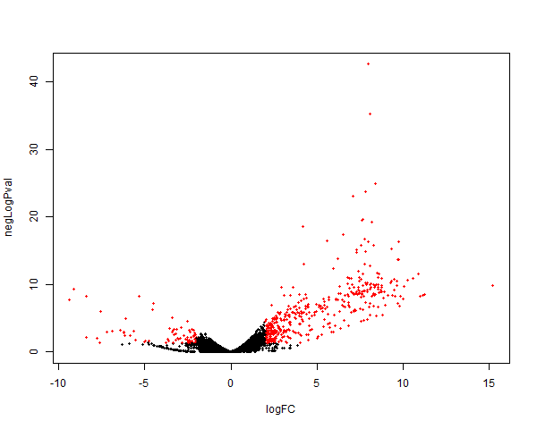

Negative Log of the p-value against Log Fold Change in expression level comparing Male to Female sex variables among six *T. adelaidensis* individuals. Red dots indicate transcripts with a significant change between sexes, with p-values <0.05 and *also* a log fold change >2. Counts calculated using Kallisto and EdgeR, for short-read poly(A) selected mRNA sequenced from kidney tissue of six *Tiliqua adelaidensis* individuals, three collected in autumn and three collected in spring, sequenced using Illumina Hi-Seq PE short-read sequencing. Reference sequence isolated from *Tiliqua adelaidensis* skink ID: G6, a representative individual for Pacific Biosciences Iso-Seq long-read transcript sequencing and annotation to generate full length reference transcripts.

```r
volcanoData_Sex <- cbind(results_Sex$table$logFC, -log10(results_Sex$table$PValue))
colnames(volcanoData_Sex) <- c("logFC", "negLogPval")
DEGs_Sex <- results_Sex$table$PValue < 0.05 & abs(results_Sex$table$logFC) >
    2

point.col_Sex <- ifelse(DEGs_Sex, "red", "black")
png("volcanoData_Sex.png", width = 600)
plot(volcanoData_Sex, pch = 16, col = point.col_Sex, cex = 0.5)
# pch is shape 1-26 are vectors, cex is size
```

## Sequencing Batch Effects

Note G1, G2, G3, G4, G5 and G8 were all sequenced together on an Illumina Hiseq and library prep was done with the same kit. G6 and G7 were later prepared in a separate batch using a different kit and sequenced on an Illumina Hiseq with fewer samples, and have a much higher read depth. These 2 represent a September Male, and March Female, respectively.

The removal of G6 and G7 from the dataset results in two groups of 3 per season, each with 2 females and 1 male, as analysed above. The below analyses have been provided for comparison of how group manipulation and inclusion of these samples affects results.

## Eight *T. adelaidensis* Individuals Collected Between Two Seasonal Periods.

**Exploration of all Eight samples by each group factor:**

Import the data:

```r
# create paths
setwd("~/@Uni/@Flinders University PhD/RWorkingDir/R-kallisto-clstr/kallisto-clstr/")
DIR8 <- ("~/@Uni/@Flinders University PhD/RWorkingDir/R-kallisto-clstr/kallisto-clstr/")
head(DIR8)
```

```
## [1] "~/@Uni/@Flinders University PhD/RWorkingDir/R-kallisto-clstr/kallisto-clstr/"
```

```r
paths8 <- list.dirs(path = DIR8, full.names = FALSE, recursive = FALSE)
# the working dir only includes kallisto output for the
# kidneys at this time View(paths)
head(paths8)
```

```
## [1] "G1_SepF" "G2_SepF" "G3_MarF" "G4_MarM" "G5_SepM" "G6_SepM"
```

```r
Kcaught8 <- catchKallisto(paths8, verbose = TRUE)
```

```
## Reading G1_SepF, 9813 transcripts, 100 bootstraps
## Reading G2_SepF, 9813 transcripts, 100 bootstraps
## Reading G3_MarF, 9813 transcripts, 100 bootstraps
## Reading G4_MarM, 9813 transcripts, 100 bootstraps
## Reading G5_SepM, 9813 transcripts, 100 bootstraps
## Reading G6_SepM, 9813 transcripts, 100 bootstraps
## Reading G7_MarF, 9813 transcripts, 100 bootstraps
## Reading G8_MarF, 9813 transcripts, 100 bootstraps
```

```r
setwd("~/@Uni/@Flinders University PhD/RWorkingDir/R-kallisto-clstr")
# View(Kcaught)
```

Set the group factors. Input Sample files are listed G1-G8 Group factors are applied to the DGElist object and are the point of comparison for expression analyses.

*Season of Collection: 1 = September, 2 = March* For the purposes of consistent labelling per group factors some April collections are referred to in the March group. Accurate collection information and dates are outlined in the methods chapter.

*Individual Sex: 1 = Female, 2 = Male*

```r
# these factors correlate to season of collection. 1 =
# March, 2 = Sep.
season8_group <- factor(c(1, 1, 2, 2, 1, 1, 2, 2))

# these factors correlate to individuals sex. 1 = Female, 2
# = Male
sex8_group <- factor(c(1, 1, 1, 2, 2, 2, 1, 1))
```

### Group Factor: **Season**

Create the EdgeR DGE list

```r
dge_Season8 <- DGEList(counts = Kcaught8$counts/Kcaught8$annotation$Overdispersion,
    genes = Kcaught8$annotation, group = season8_group)
# View(dge_Season8)
names(dge_Season8)
```

```
## [1] "counts"  "samples" "genes"
```

```r
dge_Season8
```

```
## An object of class "DGEList"
## $counts
##                                                       G1_SepF     G2_SepF
## PB.2.1|002537|path0:1-1624(+)|transcript/18304      278.00000  218.000000
## PB.3.2|00361c|path0:43-2240(+)|transcript/10564    1208.00000 1143.000000
## PB.10.1|004815|path1:5-1713(+)|transcript/17534       0.00000    5.206985
## PB.11.1|004815|path2:1-3039(+)|transcript/3426       44.12913   56.325347
## PB.11.2|004815|path2:1047-3035(+)|transcript/13401    0.00000    0.000000
##                                                       G3_MarF     G4_MarM
## PB.2.1|002537|path0:1-1624(+)|transcript/18304      99.000000  170.000000
## PB.3.2|00361c|path0:43-2240(+)|transcript/10564    990.000000 1467.000000
## PB.10.1|004815|path1:5-1713(+)|transcript/17534      2.445102    1.920669
## PB.11.1|004815|path2:1-3039(+)|transcript/3426      20.417263   17.146414
## PB.11.2|004815|path2:1047-3035(+)|transcript/13401   0.000000    0.000000
##                                                       G5_SepM    G6_SepM
## PB.2.1|002537|path0:1-1624(+)|transcript/18304     131.000000  793.00000
## PB.3.2|00361c|path0:43-2240(+)|transcript/10564    652.000000 9810.00000
## PB.10.1|004815|path1:5-1713(+)|transcript/17534      5.249977   75.81151
## PB.11.1|004815|path2:1-3039(+)|transcript/3426      58.438180 6815.29409
## PB.11.2|004815|path2:1047-3035(+)|transcript/13401   0.000000   62.63286
##                                                        G7_MarF     G8_MarF
## PB.2.1|002537|path0:1-1624(+)|transcript/18304       561.00000  225.000000
## PB.3.2|00361c|path0:43-2240(+)|transcript/10564    12443.00000 2302.000000
## PB.10.1|004815|path1:5-1713(+)|transcript/17534       57.12165    4.317232
## PB.11.1|004815|path2:1-3039(+)|transcript/3426      3215.92340   14.869331
## PB.11.2|004815|path2:1047-3035(+)|transcript/13401    55.19076    0.000000
## 9808 more rows ...
##
## $samples
##         group lib.size norm.factors
## G1_SepF     1  9760098            1
## G2_SepF     1  9760939            1
## G3_MarF     2  9745167            1
## G4_MarM     2  9855867            1
## G5_SepM     1  8598755            1
## G6_SepM     1 41290113            1
## G7_MarF     2 43632769            1
## G8_MarF     2 10009376            1
##
## $genes
##                                                    Length EffectiveLength
## PB.2.1|002537|path0:1-1624(+)|transcript/18304       1530        1207.711
## PB.3.2|00361c|path0:43-2240(+)|transcript/10564      2065        1742.711
## PB.10.1|004815|path1:5-1713(+)|transcript/17534      1612        1289.711
## PB.11.1|004815|path2:1-3039(+)|transcript/3426       2999        2676.711
## PB.11.2|004815|path2:1047-3035(+)|transcript/13401   1965        1642.711
##                                                    Overdispersion
## PB.2.1|002537|path0:1-1624(+)|transcript/18304           1.000000
## PB.3.2|00361c|path0:43-2240(+)|transcript/10564          1.000000
## PB.10.1|004815|path1:5-1713(+)|transcript/17534          2.960918
## PB.11.1|004815|path2:1-3039(+)|transcript/3426           1.359646
## PB.11.2|004815|path2:1047-3035(+)|transcript/13401       2.524871
## 9808 more rows ...
```

Obtain Counts Per Million

```r
myTPM_Season8 <- dge_Season8$counts
# head(myTPM_Season8)
```

### Initial Data Exploration

```r
# Which values in myCPM are greater than 0.5?
thresh_Season8 <- myTPM_Season8 > 0.5
# This produces a logical matrix with TRUEs and FALSEs
# head(thresh_Season8)
```

Insert colour pallate for following visualisations consistency

```r
myPalette8 <- c("#999999", "#F0E442", "#56B4E9", "#009E73", "#D55E00",
    "#0072B2", "#E69F00", "#CC79A7")
```

Plot CPM distribution with logged CPM

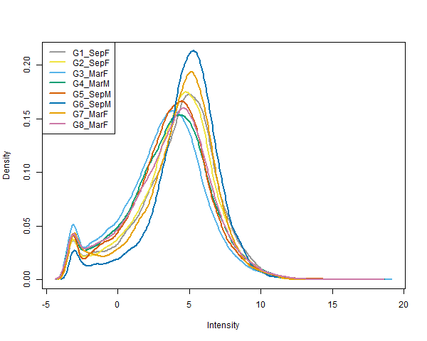

Log Counts per million Densities, calculated using Kallisto and displayed in EdgeR, for short-read poly(A) selected mRNA sequenced from kidney tissue of eight *Tiliqua adelaidensis* individuals, four collected in autumn and four collected in spring, sequenced using Illumina Hi-Seq PE short-read sequencing. Reference sequence isolated from *Tiliqua adelaidensis* skink ID: G6, a representative individual for Pacific Biosciences Iso-Seq long-read transcript sequencing and annotation to generate full length reference transcripts. Season and Sex are indicated in labels: Sep = September (spring), Mar = March (autumn), F =Female, M=Male. Samples G6 and G7 are subject to batch effects due to different cDNA synthesis methods and sequencing runs.

```r
# export the plot as png
png("plotDensities_Season8.png", width = 600)
unfilteredExpr_Season8 <- cpm(dge_Season8, log = T)
plotDensities(unfilteredExpr_Season8, col = myPalette8, legend = TRUE)
```

Visualise library sizes per sample

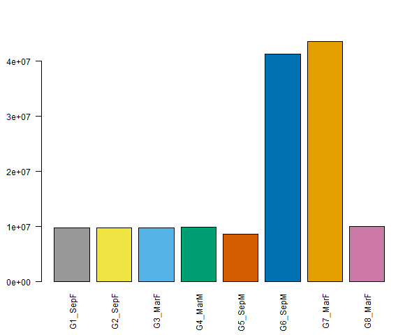

Library size of read counts calculated using Kallisto and displayed in EdgeR, for short-read poly(A) selected mRNA sequenced from kidney tissue of eight *Tiliqua adelaidensis* individuals, four collected in autumn and four collected in spring, sequenced using Illumina Hi-Seq PE short-read sequencing. Reference sequence isolated from *Tiliqua adelaidensis* skink ID: G6, a representative individual for Pacific Biosciences Iso-Seq long-read transcript sequencing and annotation to generate full length reference transcripts. Season and Sex are indicated in labels: Sep = September (spring), Mar = March (autumn), F =Female, M=Male. Samples G6 and G7 are subject to batch effects due to different cDNA synthesis methods and sequencing runs.

```r
# The names argument tells the barplot to use the sample
# names on the x-axis The las argument rotates the axis
# names export the plot as png
png("Barplot.LibSize_Season8.png", width = 600)
barplot(dge_Season8$samples$lib.size, names = colnames(dge_Season8),
    las = 2, col = myPalette8)
# title('Barplot of library sizes')
```

Visualise transcript total estimated counts per sample

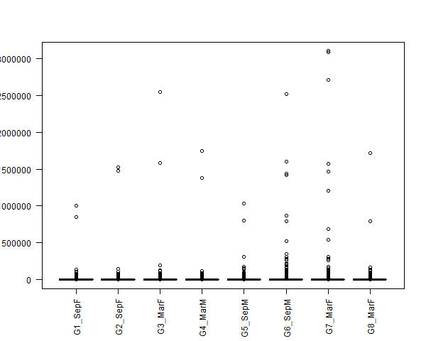

Total estimated counts, calculated using Kallisto and displayed in EdgeR, for short-read poly(A) selected mRNA sequenced from kidney tissue of eight *Tiliqua adelaidensis* individuals, four collected in autumn and four collected in spring, sequenced using Illumina Hi-Seq PE short-read sequencing. Reference sequence isolated from *Tiliqua adelaidensis* skink ID: G6, a representative individual for Pacific Biosciences Iso-Seq long-read transcript sequencing and annotation to generate full length reference transcripts. Season and Sex are indicated in labels: Sep = September (spring), Mar = March (autumn), F =Female, M=Male. Samples G6 and G7 are subject to batch effects due to different cDNA synthesis methods and sequencing runs.

```r
# export the plot as png
png("Boxplot.Counts_Season8.png", width = 600)
boxplot(dge_Season8$counts, col = myPalette8, las = 2, legend = TRUE)
# title('Boxplot of total unfiltered Counts')
```

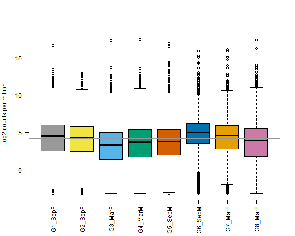

Log2 of estimated counts per million, calculated using Kallisto and displayed in EdgeR, for short-read poly(A) selected mRNA sequenced from kidney tissue of eight *Tiliqua adelaidensis* individuals, four collected in autumn and four collected in spring, sequenced using Illumina Hi-Seq PE short-read sequencing. Reference sequence isolated from *Tiliqua adelaidensis* skink ID: G6, a representative individual for Pacific Biosciences Iso-Seq long-read transcript sequencing and annotation to generate full length reference transcripts. Season and Sex are indicated in labels: Sep = September (spring), Mar = March (autumn), F =Female, M=Male. Samples G6 and G7 are subject to batch effects due to different cDNA synthesis methods and sequencing runs.

```r
# Get log2 counts per million
logcounts_Season8 <- cpm(dge_Season8, log = TRUE)
# Check distributions of samples using boxplots export the
# plot as png
png("boxplot.CPM_Season8.png", width = 600)
boxplot(logcounts_Season8, xlab = "", ylab = "Log2 counts per million",
    las = 2, col = myPalette8, legend = TRUE)
# Let's add a blue horizontal line that corresponds to the
# median logCPM
abline(h = median(logcounts_Season8), col = myPalette8, legend = TRUE)
# title('Boxplots of log Counts Per Million')
```

Visualise sample variation using an MDS plot

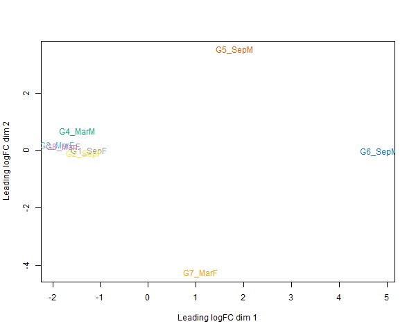

MDS plot of variation among eight *T. adelaidensis* individuals. Counts calculated using Kallisto and displayed in EdgeR, for short-read poly(A) selected mRNA sequenced from kidney tissue of eight *Tiliqua adelaidensis* individuals, four collected in autumn and four collected in spring, sequenced using Illumina Hi-Seq PE short-read sequencing. Reference sequence isolated from *Tiliqua adelaidensis* skink ID: G6, a representative individual for Pacific Biosciences Iso-Seq long-read transcript sequencing and annotation to generate full length reference transcripts. Season and Sex are indicated in labels: Sep = September (spring), Mar = March (autumn), F =Female, M=Male. Samples G6 and G7 are subject to batch effects due to different cDNA synthesis methods and sequencing runs.

```r
# export the plot as png
png("MDS_Season8.png", width = 600)
plotMDS(dge_Season8, col = myPalette8)
# title('MDS plot')
```

### Calculations

```r
# Data with actual counts, not TPM = 'dge'
# head(dge_Season8) head(myTPM_Season8)
```

filter out genes with less than 5 reads in 2 samples for each transcript

```r
filter_Season8 <- apply(dge_Season8, 1, function(x) length(x[x >
    5]) >= 2)
filtered_Season8 <- dge_Season8[filter_Season8, ]
# head(filtered_Season8)
```

Run calculations

```r
dge_Season8 <- calcNormFactors(dge_Season8)
dge_Season8 <- estimateCommonDisp(dge_Season8)
dge_Season8 <- estimateTagwiseDisp(dge_Season8)
```

```r
dge_Season8$common.dispersion
```

```
## [1] 0.5201665
```

```r
head(dge_Season8$tagwise.dispersion)
```

```
## [1] 0.3175575 0.2989024 0.8628780 1.1229636 2.0589261 0.8799119
```

Note that filtering did not change the appearance of the MDS plot

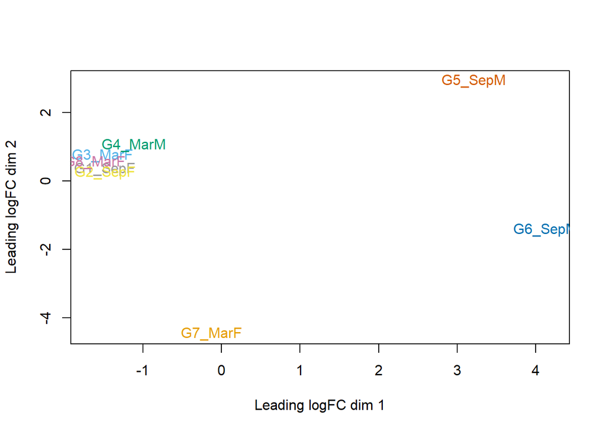

```r
plotMDS(dge_Season8, col = myPalette8)
```

### Differentially Expressed Genes:

View the top ten ‘differentially expressed genes’

```r
results_Season8 <- exactTest(dge_Season8)
topTags(results_Season8)
```

```
## Comparison of groups:  2-1
##                                                       Length EffectiveLength
## PB.499.11|124cf9|path4:2108-4109(+)|transcript/7418     2000       1677.7106
## PB.3353.1|7cf053|path5:1-7730(+)|transcript/10          7701       7378.7106
## PB.7745.1|transcript/17825:1-1637(+)|transcript/17825   1608       1285.7106
## PB.1055.1|295311|path2:1-1979(+)|transcript/12857       1976       1653.7106
## PB.3353.2|7cf053|path5:2504-7730(+)|transcript/274      5192       4869.7106
## PB.3029.5|6fe444|path1:5-2780(+)|transcript/5123        2524       2201.7106
## PB.4788.1|b34d56|path10:2-1859(+)|transcript/15227      1771       1448.7106
## PB.6088.16|e88f16|path1:1012-2792(+)|transcript/15476   1780       1457.7106
## PB.621.2|172e3f|path6:3-1224(+)|transcript/21583        1227        904.7106
## PB.840.1|1eedc5|path0:1-2091(+)|transcript/11690        2059       1736.7106
##                                                       Overdispersion      logFC
## PB.499.11|124cf9|path4:2108-4109(+)|transcript/7418         1.767895  -3.568347
## PB.3353.1|7cf053|path5:1-7730(+)|transcript/10              2.543874  -6.995545
## PB.7745.1|transcript/17825:1-1637(+)|transcript/17825       1.000000  -5.135802
## PB.1055.1|295311|path2:1-1979(+)|transcript/12857           1.000000  -6.242521
## PB.3353.2|7cf053|path5:2504-7730(+)|transcript/274          4.234974  -7.381847
## PB.3029.5|6fe444|path1:5-2780(+)|transcript/5123            1.124468  -9.597014
## PB.4788.1|b34d56|path10:2-1859(+)|transcript/15227          1.416655 -10.043618
## PB.6088.16|e88f16|path1:1012-2792(+)|transcript/15476       2.382893  -8.787069
## PB.621.2|172e3f|path6:3-1224(+)|transcript/21583            1.363178 -13.764707
## PB.840.1|1eedc5|path0:1-2091(+)|transcript/11690            1.000000  -7.383704
##                                                         logCPM       PValue
## PB.499.11|124cf9|path4:2108-4109(+)|transcript/7418   5.173178 4.544680e-09
## PB.3353.1|7cf053|path5:1-7730(+)|transcript/10        5.885474 2.200857e-07
## PB.7745.1|transcript/17825:1-1637(+)|transcript/17825 2.901392 2.927072e-07
## PB.1055.1|295311|path2:1-1979(+)|transcript/12857     4.710647 6.060042e-07
## PB.3353.2|7cf053|path5:2504-7730(+)|transcript/274    4.735994 6.095150e-07
## PB.3029.5|6fe444|path1:5-2780(+)|transcript/5123      7.625550 6.300014e-07
## PB.4788.1|b34d56|path10:2-1859(+)|transcript/15227    7.822567 6.708151e-07
## PB.6088.16|e88f16|path1:1012-2792(+)|transcript/15476 6.838386 7.879104e-07
## PB.621.2|172e3f|path6:3-1224(+)|transcript/21583      5.355191 9.360938e-07
## PB.840.1|1eedc5|path0:1-2091(+)|transcript/11690      5.001310 1.026803e-06
##                                                                FDR
## PB.499.11|124cf9|path4:2108-4109(+)|transcript/7418   4.459695e-05
## PB.3353.1|7cf053|path5:1-7730(+)|transcript/10        9.286326e-04
## PB.7745.1|transcript/17825:1-1637(+)|transcript/17825 9.286326e-04
## PB.1055.1|295311|path2:1-1979(+)|transcript/12857     9.286326e-04
## PB.3353.2|7cf053|path5:2504-7730(+)|transcript/274    9.286326e-04
## PB.3029.5|6fe444|path1:5-2780(+)|transcript/5123      9.286326e-04
## PB.4788.1|b34d56|path10:2-1859(+)|transcript/15227    9.286326e-04
## PB.6088.16|e88f16|path1:1012-2792(+)|transcript/15476 9.286326e-04
## PB.621.2|172e3f|path6:3-1224(+)|transcript/21583      9.286326e-04
## PB.840.1|1eedc5|path0:1-2091(+)|transcript/11690      9.286326e-04
```

Output summary expression data

```r
dim(results_Season8)
```

```
## [1] 9813    3
```

```r
summary(de_Season8 <- decideTests(results_Season8))
```

```
##         2-1
## Down    210
## NotSig 9598
## Up        5
```

```r
Summary_Season8 <- (de_Season8 <- decideTests(results_Season8))

write.table(Summary_Season8, file = "summary_Season8.txt")

detags_Season8 <- rownames(dge_Season8)[as.logical(de_Season8)]
```

Visualise with a plotsmear

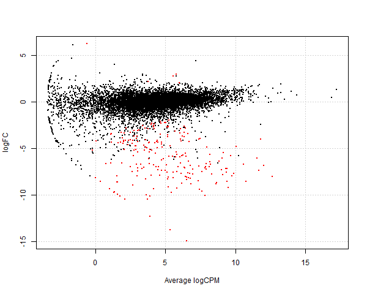

Log Fold Change vs average Log counts per million for expression level comparing March to September among eight *T. adelaidensis* individuals. Red dots indicate transcripts with a significant change over season, with p-values <0.05. Counts calculated using Kallisto and displayed in EdgeR, for short-read poly(A) selected mRNA sequenced from kidney tissue of eight *Tiliqua adelaidensis* individuals, four collected in autumn and four collected in spring, sequenced using Illumina Hi-Seq PE short-read sequencing. Reference sequence isolated from *Tiliqua adelaidensis* skink ID: G6, a representative individual for Pacific Biosciences Iso-Seq long-read transcript sequencing and annotation to generate full length reference transcripts. Samples G6 and G7 are subject to batch effects due to different cDNA synthesis methods and sequencing runs.

```r
detags_Season8 <- rownames(dge_Season8)[as.logical(de_Season8)]
# export the plot as png
png("plotSmear_Season8.png", width = 600)
plotSmear(results_Season8, de.tags = detags_Season8)
```

Visualise with a volcano plot

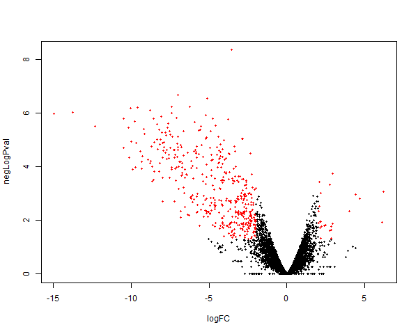

Negative Log of the p-value against Log Fold Change in expression level comparing March to September among eight *T. adelaidensis* individuals. Red dots indicate transcripts with a significant change over season, with p-values <0.05 and *also* a log fold change >2. Counts calculated using Kallisto and displayed in EdgeR, for short-read poly(A) selected mRNA sequenced from kidney tissue of eight *Tiliqua adelaidensis* individuals, four collected in autumn and four collected in spring, sequenced using Illumina Hi-Seq PE short-read sequencing. Reference sequence isolated from *Tiliqua adelaidensis* skink ID: G6, a representative individual for Pacific Biosciences Iso-Seq long-read transcript sequencing and annotation to generate full length reference transcripts. Samples G6 and G7 are subject to batch effects due to different cDNA synthesis methods and sequencing runs.

```r
# export the plot as png
png("volcanoData_Season8.png", width = 600)
volcanoData_Season8 <- cbind(results_Season8$table$logFC, -log10(results_Season8$table$PValue))
colnames(volcanoData_Season8) <- c("logFC", "negLogPval")
DEGs_Season8 <- results_Season8$table$PValue < 0.05 & abs(results_Season8$table$logFC) >
    2
point.col_Season8 <- ifelse(DEGs_Season8, "red", "black")
plot(volcanoData_Season8, pch = 16, col = point.col_Season8,
    cex = 0.5)
```

### Group Factor: **Sex**

Create the EdgeR DGE list

```r
dge_Sex8 <- DGEList(counts = Kcaught8$counts/Kcaught8$annotation$Overdispersion,
    genes = Kcaught8$annotation, group = sex8_group)
# View(dge_Sex8)
names(dge_Sex8)
```

```
## [1] "counts"  "samples" "genes"
```

```r
dge_Sex8
```

```
## An object of class "DGEList"
## $counts
##                                                       G1_SepF     G2_SepF
## PB.2.1|002537|path0:1-1624(+)|transcript/18304      278.00000  218.000000
## PB.3.2|00361c|path0:43-2240(+)|transcript/10564    1208.00000 1143.000000
## PB.10.1|004815|path1:5-1713(+)|transcript/17534       0.00000    5.206985
## PB.11.1|004815|path2:1-3039(+)|transcript/3426       44.12913   56.325347
## PB.11.2|004815|path2:1047-3035(+)|transcript/13401    0.00000    0.000000
##                                                       G3_MarF     G4_MarM
## PB.2.1|002537|path0:1-1624(+)|transcript/18304      99.000000  170.000000
## PB.3.2|00361c|path0:43-2240(+)|transcript/10564    990.000000 1467.000000
## PB.10.1|004815|path1:5-1713(+)|transcript/17534      2.445102    1.920669
## PB.11.1|004815|path2:1-3039(+)|transcript/3426      20.417263   17.146414
## PB.11.2|004815|path2:1047-3035(+)|transcript/13401   0.000000    0.000000
##                                                       G5_SepM    G6_SepM
## PB.2.1|002537|path0:1-1624(+)|transcript/18304     131.000000  793.00000
## PB.3.2|00361c|path0:43-2240(+)|transcript/10564    652.000000 9810.00000
## PB.10.1|004815|path1:5-1713(+)|transcript/17534      5.249977   75.81151
## PB.11.1|004815|path2:1-3039(+)|transcript/3426      58.438180 6815.29409
## PB.11.2|004815|path2:1047-3035(+)|transcript/13401   0.000000   62.63286
##                                                        G7_MarF     G8_MarF
## PB.2.1|002537|path0:1-1624(+)|transcript/18304       561.00000  225.000000
## PB.3.2|00361c|path0:43-2240(+)|transcript/10564    12443.00000 2302.000000
## PB.10.1|004815|path1:5-1713(+)|transcript/17534       57.12165    4.317232
## PB.11.1|004815|path2:1-3039(+)|transcript/3426      3215.92340   14.869331
## PB.11.2|004815|path2:1047-3035(+)|transcript/13401    55.19076    0.000000
## 9808 more rows ...
##
## $samples
##         group lib.size norm.factors
## G1_SepF     1  9760098            1
## G2_SepF     1  9760939            1
## G3_MarF     1  9745167            1
## G4_MarM     2  9855867            1
## G5_SepM     2  8598755            1
## G6_SepM     2 41290113            1
## G7_MarF     1 43632769            1
## G8_MarF     1 10009376            1
##
## $genes
##                                                    Length EffectiveLength
## PB.2.1|002537|path0:1-1624(+)|transcript/18304       1530        1207.711
## PB.3.2|00361c|path0:43-2240(+)|transcript/10564      2065        1742.711
## PB.10.1|004815|path1:5-1713(+)|transcript/17534      1612        1289.711
## PB.11.1|004815|path2:1-3039(+)|transcript/3426       2999        2676.711
## PB.11.2|004815|path2:1047-3035(+)|transcript/13401   1965        1642.711
##                                                    Overdispersion
## PB.2.1|002537|path0:1-1624(+)|transcript/18304           1.000000
## PB.3.2|00361c|path0:43-2240(+)|transcript/10564          1.000000
## PB.10.1|004815|path1:5-1713(+)|transcript/17534          2.960918
## PB.11.1|004815|path2:1-3039(+)|transcript/3426           1.359646
## PB.11.2|004815|path2:1047-3035(+)|transcript/13401       2.524871
## 9808 more rows ...
```

```r
# Obtain Counts Per Million
myTPM_Sex8 <- dge_Sex8$counts
# Have a look at the output head(myTPM_Sex8)
```

### Initial Data Exploration

```r
# Which values in myCPM are greater than 0.5?
thresh_Sex8 <- myTPM_Sex8 > 0.5
# This produces a logical matrix with TRUEs and FALSEs
# head(thresh_Sex8)
```

Raw Counts per million and library sizes will be consistent with the Season comparison above. There is no need to plot them again however scripts are included to create separate R objects for downstream application.

CPM distribution with logged CPM

```r
# export the plot as png
png("plotDensities_Sex8.png", width = 600)
unfilteredExpr_Sex8 <- cpm(dge_Sex8, log = T)
plotDensities(unfilteredExpr_Sex8, col = myPalette8, legend = TRUE)
```

Library sizes per sample

```r
# The names argument tells the barplot to use the sample
# names on the x-axis The las argument rotates the axis
# names export the plot as png
png("Barplot.LibSize_Sex8.png", width = 600)
barplot(dge_Sex8$samples$lib.size, names = colnames(dge_Sex8),
    las = 2, col = myPalette8)
# title('Barplot of library sizes')
```

Transcript total estimated counts per sample

```r
# export the plot as png
png("Boxplot.Counts_Sex8.png", width = 600)
boxplot(dge_Sex8$counts, col = myPalette8, las = 2, legend = TRUE)
# title('Boxplot of total unfiltered Counts')
```

Logged total estimated transcript counts per sample

```r
# Get log2 counts per million
logcounts_Sex8 <- cpm(dge_Sex8, log = TRUE)
# Check distributions of samples using boxplots export the
# plot as png
png("boxplot.CPM_Sex8.png", width = 600)
boxplot(logcounts_Sex8, xlab = "", ylab = "Log2 counts per million",
    las = 2, col = myPalette8, legend = TRUE)
# Let's add a blue horizontal line that corresponds to the
# median logCPM
abline(h = median(logcounts_Sex8), col = myPalette8, legend = TRUE)
# title('Boxplots of log Counts Per Million')
```

### Calculations

```r
# Data with actual counts, not TPM = 'dge' head(dge_Sex8)
# head(myTPM_Sex8)
```

filter out genes with less than 5 reads in 2 samples for each transcript

```r
filter_Sex8 <- apply(dge_Sex8, 1, function(x) length(x[x > 5]) >=
    2)
filtered_Sex8 <- dge_Sex8[filter_Sex8, ]
# head(filtered_Sex8)
```

Run calculations

```r
dge_Sex8 <- calcNormFactors(dge_Sex8)
dge_Sex8 <- estimateCommonDisp(dge_Sex8)
dge_Sex8 <- estimateTagwiseDisp(dge_Sex8)
```

```r
dge_Sex8$common.dispersion
```

```
## [1] 0.4957059
```

```r
head(dge_Sex8$tagwise.dispersion)
```

```
## [1] 0.3077159 0.3081643 0.8345605 1.0635014 2.0240359 0.8801331
```

### Differentially Expressed Genes:

View the top ten ‘differentially expressed genes’

```r
results_Sex8 <- exactTest(dge_Sex8)
topTags(results_Sex8)
```

```
## Comparison of groups:  2-1
##                                                    Length EffectiveLength
## PB.2770.1|6751e7|path1:1-1210(+)|transcript/22021    1103        780.7106
## PB.2769.1|6751e7|path0:4-1327(+)|transcript/21195    1136        813.7106
## PB.3895.1|91ba83|path6:1-1594(+)|transcript/18563    1376       1053.7106
## PB.6451.1|f62586|path2:1-2617(+)|transcript/23694     736        413.9638
## PB.979.1|25edbb|path0:1-3100(+)|transcript/3575      3066       2743.7106
## PB.4153.1|9a8a98|path29:1-1042(+)|transcript/22949    862        539.7749
## PB.4152.1|9a8a98|path2:1-992(+)|transcript/22901      896        573.7631
## PB.2493.6|5d0eeb|path5:27-5305(+)|transcript/20823   1337       1014.7106
## PB.6452.1|f62586|path3:1-2621(+)|transcript/24182     633        311.4422
## PB.637.1|1826ff|path3:1-1155(+)|transcript/22860      905        582.7631
##                                                    Overdispersion    logFC
## PB.2770.1|6751e7|path1:1-1210(+)|transcript/22021        3.909377 8.427189
## PB.2769.1|6751e7|path0:4-1327(+)|transcript/21195        1.778063 8.498502
## PB.3895.1|91ba83|path6:1-1594(+)|transcript/18563        3.281779 9.877587
## PB.6451.1|f62586|path2:1-2617(+)|transcript/23694        2.206536 8.379631
## PB.979.1|25edbb|path0:1-3100(+)|transcript/3575          1.000000 8.825922
## PB.4153.1|9a8a98|path29:1-1042(+)|transcript/22949       2.017518 7.786646
## PB.4152.1|9a8a98|path2:1-992(+)|transcript/22901         1.851161 8.076026
## PB.2493.6|5d0eeb|path5:27-5305(+)|transcript/20823       7.349539 9.470585
## PB.6452.1|f62586|path3:1-2621(+)|transcript/24182        2.348219 8.535088
## PB.637.1|1826ff|path3:1-1155(+)|transcript/22860         1.155099 7.594306
##                                                      logCPM       PValue
## PB.2770.1|6751e7|path1:1-1210(+)|transcript/22021  5.581957 5.041529e-32
## PB.2769.1|6751e7|path0:4-1327(+)|transcript/21195  8.808743 4.881766e-27
## PB.3895.1|91ba83|path6:1-1594(+)|transcript/18563  7.290776 8.269517e-19
## PB.6451.1|f62586|path2:1-2617(+)|transcript/23694  5.379825 1.467057e-18
## PB.979.1|25edbb|path0:1-3100(+)|transcript/3575    4.283730 3.452531e-18
## PB.4153.1|9a8a98|path29:1-1042(+)|transcript/22949 4.904003 3.111298e-17
## PB.4152.1|9a8a98|path2:1-992(+)|transcript/22901   6.272961 8.781115e-17
## PB.2493.6|5d0eeb|path5:27-5305(+)|transcript/20823 5.652139 7.496662e-16
## PB.6452.1|f62586|path3:1-2621(+)|transcript/24182  3.542180 1.769362e-15
## PB.637.1|1826ff|path3:1-1155(+)|transcript/22860   7.555428 3.678419e-15
##                                                             FDR
## PB.2770.1|6751e7|path1:1-1210(+)|transcript/22021  4.947252e-28
## PB.2769.1|6751e7|path0:4-1327(+)|transcript/21195  2.395239e-23
## PB.3895.1|91ba83|path6:1-1594(+)|transcript/18563  2.704959e-15
## PB.6451.1|f62586|path2:1-2617(+)|transcript/23694  3.599057e-15
## PB.979.1|25edbb|path0:1-3100(+)|transcript/3575    6.775938e-15
## PB.4153.1|9a8a98|path29:1-1042(+)|transcript/22949 5.088528e-14
## PB.4152.1|9a8a98|path2:1-992(+)|transcript/22901   1.230987e-13
## PB.2493.6|5d0eeb|path5:27-5305(+)|transcript/20823 9.195593e-13
## PB.6452.1|f62586|path3:1-2621(+)|transcript/24182  1.929195e-12
## PB.637.1|1826ff|path3:1-1155(+)|transcript/22860   3.609632e-12
```

Output summary expression data

```r
dim(results_Sex8)
```

```
## [1] 9813    3
```

```r
summary(de_Sex8 <- decideTests(results_Sex8))
```

```
##         2-1
## Down      2
## NotSig 9490
## Up      321
```

```r
Summary_Sex8 <- (de_Sex8 <- decideTests(results_Sex8))

write.table(Summary_Sex8, file = "summary_Sex8.txt")

detags_Sex8 <- rownames(dge_Sex8)[as.logical(de_Sex8)]
```

Visualise with a plotsmear

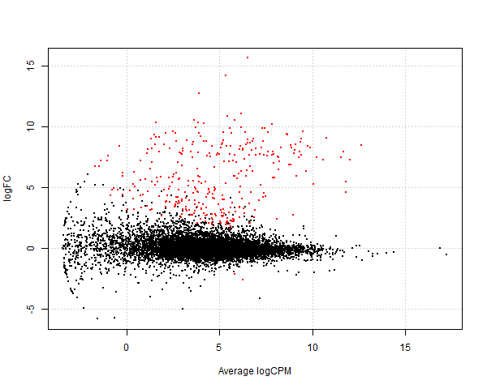

Log Fold Change vs average Log counts per million for expression level comparing Male to Female as variables among eight *T. adelaidensis* individuals. Red dots indicate transcripts with a significant change between sexes, with p-values <0.05. Counts calculated using Kallisto and displayed in EdgeR, for short-read poly(A) selected mRNA sequenced from kidney tissue of eight *Tiliqua adelaidensis* individuals, four collected in autumn and four collected in spring, sequenced using Illumina Hi-Seq PE short-read sequencing. Reference sequence isolated from *Tiliqua adelaidensis* skink ID: G6, a representative individual for Pacific Biosciences Iso-Seq long-read transcript sequencing and annotation to generate full length reference transcripts. Samples G6 and G7 are subject to batch effects due to different cDNA synthesis methods and sequencing runs.

```r
# export the plot as png
png("plotSmear_Sex8.png", width = 600)
plotSmear(results_Sex8, de.tags = detags_Sex8)
```

Visualise with a volcano plot

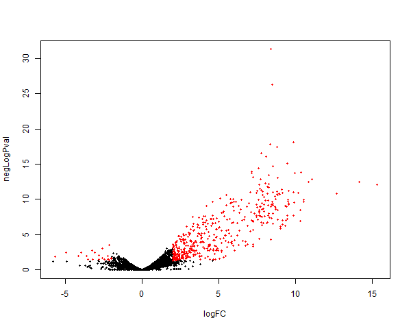

Negative Log of the p-value against Log Fold Change in expression level comparing Male to Female as variables among eight *T. adelaidensis* individuals. Red dots indicate transcripts with a significant change between sexes, with p-values <0.05 and *also* a log fold change >2. Counts calculated using Kallisto and displayed in EdgeR, for short-read poly(A) selected mRNA sequenced from kidney tissue of eight *Tiliqua adelaidensis* individuals, four collected in autumn and four collected in spring, sequenced using Illumina Hi-Seq PE short-read sequencing. Reference sequence isolated from *Tiliqua adelaidensis* skink ID: G6, a representative individual for Pacific Biosciences Iso-Seq long-read transcript sequencing and annotation to generate full length reference transcripts. Samples G6 and G7 are subject to batch effects due to different cDNA synthesis methods and sequencing runs.

```r
# export the plot as png
png("volcanoData_Sex8.png", width = 600)
volcanoData_Sex8 <- cbind(results_Sex8$table$logFC, -log10(results_Sex8$table$PValue))
colnames(volcanoData_Sex8) <- c("logFC", "negLogPval")
DEGs_Sex8 <- results_Sex8$table$PValue < 0.05 & abs(results_Sex8$table$logFC) >
    2
point.col_Sex8 <- ifelse(DEGs_Sex8, "red", "black")
plot(volcanoData_Sex8, pch = 16, col = point.col_Sex8, cex = 0.5)
```